# Airline On-Time Presentation

## by Aniekan Inyang

## Investigation Overview

For this investigation, I will be looking at the characteristics of the major causes of delay for both arrival and departure. Also, look at the degree of the causes of the delay .

## Dataset Overview

This dataset reports flights in the United States, including carriers, arrival and departure delays, and reasons for delays, from 2004 to 2008.

## Distribution of Arrival delays

The arrival delay dataset takes on a range of values, between -100 and 300. The distribution of arrival delays is unimodal and skewed to the right.

[figure not shown]

## Distribution of Departure delays

The departure delay dataset takes on range of values, between -25 and 250. The distribution of departure delays is unimodal and also skewed to the right.

[figure not shown]

## Average Delay Causes

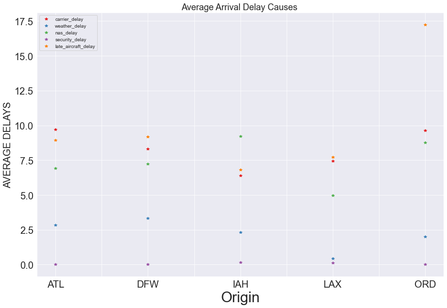